# PS6

## Instructions

Create a new markdown document where you will answer all questions. Submit (1) your code as an `.Rmd` file, and (2) a rendered html file including only what you wish to present, to the `Problem Set 6` assignment under the Assignments tab in Canvas. The problem set is due *Friday, 28 February, by 10:00 EST*. Name your files `lastname_ps06` (`.html` and `.Rmd`).

All submitted work must be your own.

## Data

For these problems, we will use a dataset of campaign contributions: `contribupdate.csv`.

We will use the following variables:

- `age`: Age (years);
- `faminc`: Household income (in $1,000 U.S. dollars);
- `given`: Campaign contributions over the past year (in U.S. dollars).
1. Load the data and store it in `contrib`.

```
##      female           educ                race          minority
##  Min.   :0.0000   Length:10054       Min.   :1.000   Min.   :0.0000
##  1st Qu.:0.0000   Class :character   1st Qu.:1.000   1st Qu.:0.0000
##  Median :0.0000   Mode  :character   Median :1.000   Median :0.0000
##  Mean   :0.4532                      Mean   :1.446   Mean   :0.1752
##  3rd Qu.:1.0000                      3rd Qu.:1.000   3rd Qu.:0.0000
##  Max.   :1.0000                      Max.   :8.000   Max.   :1.0000
##     hispanic        marstat          faminc             age
##  Min.   :1.000   Min.   :1.000   Min.   :  1.063   Min.   :18.00
##  1st Qu.:2.000   1st Qu.:1.000   1st Qu.: 46.529   1st Qu.:42.00
##  Median :2.000   Median :1.000   Median : 76.001   Median :58.00
##  Mean   :1.972   Mean   :2.399   Mean   : 90.905   Mean   :55.47
##  3rd Qu.:2.000   3rd Qu.:4.000   3rd Qu.:116.866   3rd Qu.:69.00
##  Max.   :2.000   Max.   :6.000   Max.   :498.959   Max.   :94.00
##      given
##  Min.   :   1.0
##  1st Qu.:  50.0
##  Median : 100.0
##  Mean   : 262.3
##  3rd Qu.: 250.0
##  Max.   :5000.0
```

1. Create two new variables in `contrib` that are the natural log of `faminc` and `given`. Name them `lfaminc` and `lgiven`, respectively.

## Problem 1

1. You suspect that age has a non-linear relationship with campaign contributions. You decide to model this with a quadratic term for age. Estimate the following model and store it in an object `m1`.

$$\text{given}_i = \beta_0 + \beta_1\text{age}_i + \beta_2
(\text{age}_i)^2 + u_i$$

2. Is there evidence for a quadratic relationship between `age` and `given`? Explain why or why not.

The coefficient estimate for age is 4.34 Because this is a quadratic model, the coefficient of age isn’t the constant effect of a one-unit (ie one year) increase in age – its the linear component of the effect. The actual marginal effect is the CME equation.

2. Formula for the conditional marginal effect of `age` on `given`.

$$\frac{\partial given_i}{\partial age_i}
= \beta_1 + 2\beta_2age_{i}$$

2. At what value of age does the conditional marginal effect of age reach zero? Show your work using an R code block (`echo=T`). The CME of age on contributions reaches zero at 97.93.

```r
turning_point <- -4.34239/(2*-0.02217)

turning_point
```

```
## [1] 97.93392
```

2. Plot the conditional marginal effect of `age` on `given` across values of `age`. Make sure your figure is properly labeled and looks professional. Briefly interpret the plot substantively.

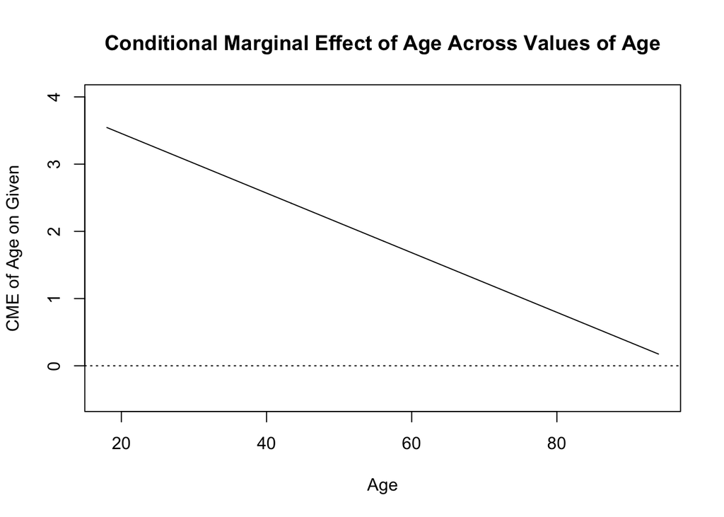

This shows us that the instantaneous rate of change or the slop of age’s effect on contributions decreases as people get older, although it (the effect of age on campaign contributions) is always positive (increases annual campaign contribution amounts, holding all else equal. For some examples. we see that at about 18-20, an additional year of age on average increases annual campaign contribution amounts by $3.5, but at 60, that’s closer to $2, and by ~90 an additional year is almost nothing.

2. Plot the predicted values of `given` across values of `age`. Briefly interpret the plot substantively.

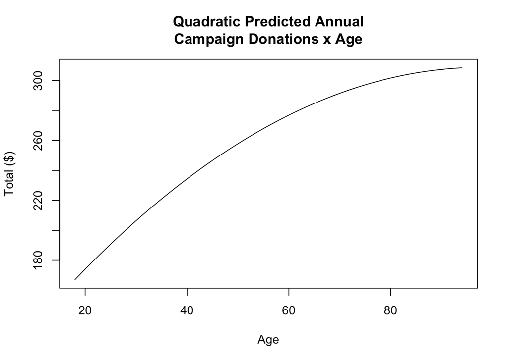

## Problem 2

1. You suspect that the impact of household income on campaign contributions is conditional on the age of an individual. Estimate the following model and store it in `m2`.

$$\text{given}_i = \beta_0 + \beta_1 \text{age}_i + \beta_2
\text{faminc}_i + \beta_3 \text{age}_i \times \text{faminc}_i + u_i$$

2. What are the marginal effects of family income on campaign contributions for individuals who are 30, 50, and 70 years old, respectively? Use the coefficients from the regression table to calculate the marginal effects and show your work using `echo=T`.

Marginal effect of faminc on campaign contrib is:

$$\frac{\partial given_i}{\partial
faminc_i} = \beta_2 + \beta_3age_{_i}$$

```r
#marginal effects of faminc on campaign contributions at 30 means

beta_faminc <- -0.75625
beta_x <- 0.04987

me_faminc_30 <- beta_faminc + beta_x * 30
me_faminc_50 <- beta_faminc + beta_x * 50
me_faminc_70 <- beta_faminc + beta_x * 70

me_faminc_30
```

```
## [1] 0.73985
```

```r
me_faminc_50
```

```
## [1] 1.73725
```

```r
me_faminc_70
```

```
## [1] 2.73465
```

```r
#oops/also via slopes
slopes(m2,
       variables = "faminc",
       newdata = datagrid(age = c(30, 50, 70)))
```

```
##
##  age Estimate Std. Error     z Pr(>|z|) 2.5 % 97.5 %
##   30     0.74     0.1407  5.26   <0.001 0.464   1.02
##   50     1.74     0.0789 22.03   <0.001 1.583   1.89
##   70     2.73     0.1027 26.62   <0.001 2.533   2.94
##
## Term: faminc
## Type: response
## Comparison: dY/dX
```

The conditional marginal effect of a one unit increase in family income at 30 is 74 cents, at 50 is $1.74, at 70 is $2.73, holding all else constant.

2. Create a plot that shows the marginal effect of family income at each value of age. Make sure your figure is properly labeled and looks professional. Briefly interpret the plot substantively.

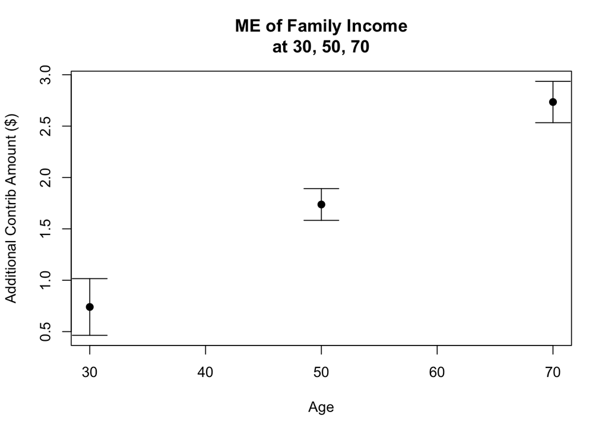

2. Create a plot that displays the predicted contributions across the range of values of family income, with age fixed at three different values: 30, 50, and 70. That is, the plot should display predicted values across income in three separate lines, each representing a different value of age. Briefly interpret the plot substantively.

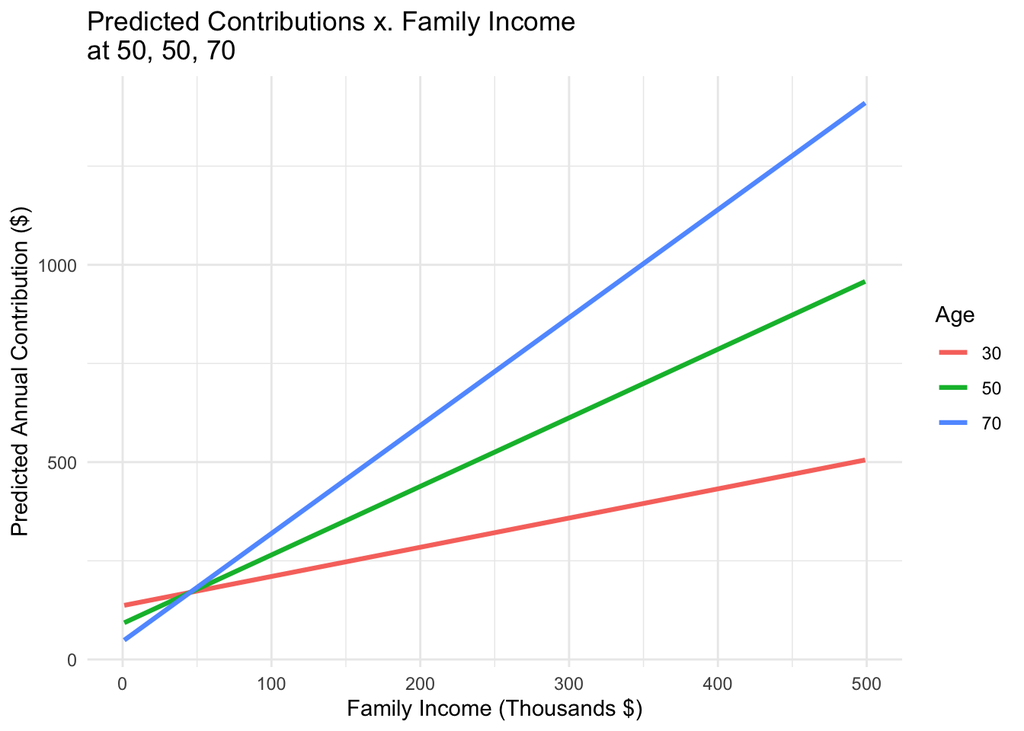

```r
#ranges
inc <- seq(min(contrib$faminc, na.rm = TRUE),
           max(contrib$faminc, na.rm = TRUE),
           length.out = 200)

ages <-c(30, 50, 70)

#all combos
new_data <- expand.grid(faminc = inc, age = ages)

#predicted contrib for each combo
new_data$predicted_contrib <- predict(m2, newdata = new_data)

#plot
ggplot(new_data, aes(x = faminc, y = predicted_contrib, color = factor(age))) +
  geom_line(linewidth = 1.1) +
  labs(
    x = "Family Income (Thousands $)",
    y = "Predicted Annual Contribution ($)",
    color = "Age",
    title = "Predicted Contributions x. Family Income\nat 50, 50, 70") +
  theme_minimal(
  )
```

## Problem 3

1. You now think you are better off modeling the relationship of contributions to family income as non-linear. Estimate the following model and store it in `m3`.

$$\ln(\text{given}_i) = \beta_0 + \beta_1 \text{age}_i + \beta_2
\ln(\text{faminc}_i) + u_i$$

```r
m3 <- lm(lgiven ~ age + lfaminc, data = contrib)
summary(m3)
```

```
##
## Call:
## lm(formula = lgiven ~ age + lfaminc, data = contrib)
##
## Residuals:
##     Min      1Q  Median      3Q     Max
## -5.3671 -0.8124 -0.0113  0.8222  5.3718
##
## Coefficients:
##              Estimate Std. Error t value Pr(>|t|)
## (Intercept) 1.4213554  0.0838498   16.95   <2e-16 ***
## age         0.0122805  0.0007608   16.14   <2e-16 ***
## lfaminc     0.5943097  0.0172040   34.55   <2e-16 ***
## ---
## Signif. codes:  0 '***' 0.001 '**' 0.01 '*' 0.05 '.' 0.1 ' ' 1
##
## Residual standard error: 1.298 on 10051 degrees of freedom
## Multiple R-squared:  0.1306, Adjusted R-squared:  0.1305
## F-statistic: 755.2 on 2 and 10051 DF,  p-value: < 2.2e-16
```

2. Write a sentence that interprets the estimate for $\beta_2$ as an elasticity. Don’t do any calculations, just use the coefficient estimate from `m3`.

$\beta_2$ is 0.594 meaning a 1 percent increase in family income is associated with a ~0.60% increase in the expected value of annual campaign contributions, holding all else constant.

3. Calculate the percentage change in `given` for a 10-year increase in `age` (use `echo=T`). Write a sentence that describes the result.

```r
perc_change <- 100*(exp(coef(m3)["age"]*10)-1)
perc_change
```

```
##      age
## 13.06645
```

On average, a 10-year increase in age increases annual campaign contributions by 13%.

4. Calculate the expected value of `given` for a 40-year-old with $90,000 in family income (i.e., `faminc = 90`). Remember that this is expected for `given` NOT `log(given)`. Use `echo=T`

```r
age40 <- 40

faminc40 <- 90

df_40 <- data.frame(age=age40, lfaminc = log(faminc40))

#predict on log scale
predicted_40 <- predict(m3, newdata = df_40, se.fit = TRUE)
pred_level <- exp(predicted_40$fit)

pred_level
```

```
##        1
## 98.18542
```

```r
#smearing correction

sigmasq <- summary(m3)$sigma^2
pred_level_sigma <- exp(predicted_40$fit + 0.5 *sigmasq)
```

Predicted value of campaign contributions for a 40 year old with $90k in family income is $98.2 dollars that year.

3. Calculate the change in the expected value of `given`, for a 60-year-old, when `faminc` changes from 50 to 100. In other words, calculate the first difference in `given` for a change in `faminc` from 50 to 100 holding `age` at 60. Use `echo=T`. Write a sentence that describes the result.

```r
#shorter way
#data frame
lastdf <- data.frame(
  age = 60,
  lfaminc = log(c(50,100))
)

#back transofm
log_vers <- predict(m3, newdata = lastdf)
level_vers <- exp(log_vers)
first_dif<-level_vers[2]-level_vers[1]

first_dif
```

```
##        2
## 45.11914
```

```r
#OLD:
#make a row for age 60 faminc 50, "" faminc 100
bot1 <- data.frame(age=60, lfaminc = log(50))
bot2 <- data.frame(age = 60, lfaminc = log(100))

#scale - to log, exponentiate for dollar
bot1_level <-exp(bot1)
bot2_level <- exp(bot2)

#first difference
first_dif <- bot2_level- bot1_level

first_dif
```

```
##   age lfaminc
## 1   0      50
```